# Praca domowa 2

## Dane

Dane wykorzystane w Pracy domowej 2 są związane z kampaniami marketingu bezpośredniego portugalskiej instytucji bankowej. Kampanie marketingowe opierały się na rozmowach telefonicznych. Często wymagany był więcej niż jeden kontakt z tym samym klientem, aby uzyskać dostęp do tego, czy produkt (lokata bankowa) zostanie (lub nie) subskrybowany. Opis wszystkich kolumn znajduje się również w pliku `README.md`.

#### Dane klienta banku

| Zmienna | Opis |
| --- | --- |
| **age** | wiek |
| **job** : admin., unknown, unemployed, management, housemaid, entrepreneur, student, blue-collar, self-employed, retired, technician, services | administrator, nieznany, bezrobotny, kierownictwo, pokojówka, przedsiębiorca, student, pracownik fizyczny, samozatrudniony, emeryt, technik, usługi |
| **marital** : married, divorced, single; note: divorced means divorced or widowed) | żonaty/zamężna, rozwiedzion_, kawaler/panna; uwaga: rozwiedzion_ oznacza rozwiedzion_ lub owdowiał_ |
| **education** : unknown, secondary, primary, tertiary | nieznane, średnie, podstawowe, wyższe |
| **default** : yes, no | czy kredyt jest niespłacany : tak, nie |
| **balance** : average yearly balance, in euros | średnie roczne saldo w euro |
| **housing** : has housing loan? yes, no | czy posiada kredyt mieszkaniowy? tak, nie |
| **loan** : has personal loan? yes, no | ma pożyczkę osobistą? tak, nie |

#### Dane związane z ostatnim kontaktem w bieżącej kampanii

| Zmienna | Opis |
| --- | --- |
| **contact** : unknown, telephone, cellular | nieznany, telefon, komórkowy |
| **day** : last contact day of the month | dzień miesiąca ostatniego kontaktu |
| **month** : last contact month of year, jan, feb, mar, …, nov, dec | miesiąc ostatniego kontaktu w roku, styczeń, luty, marzec, …, listopad, grudzień |
| **duration** : last contact duration, in seconds | czas trwania ostatniego kontaktu w sekundach |

## Zadanie 1

Weźmy pod uwagę zawody (`job`) klientów banku. Który zawód zacząco wyróżnia się w posiadaniu kredytu mieszkaniowego lub pożyczki osobistej?

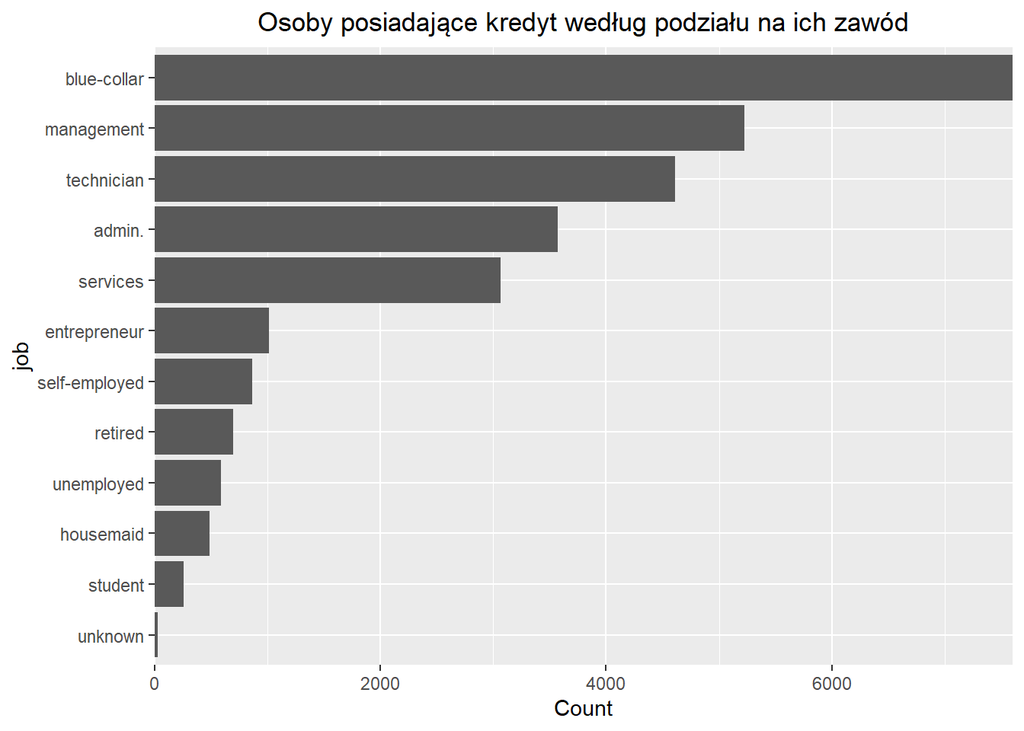

```r
df %>%
  filter(loan == "yes" | housing == "yes") %>%
  group_by(job) %>%
  summarise(Count = n()) %>%
  mutate(job = forcats::fct_reorder(job, Count) ) %>%
  ggplot(aes(y = job, x = Count)) +
  geom_col() +
  scale_x_continuous(expand = c(0,0)) +
  labs(title = "Osoby posiadające kredyt według podziału na ich zawód") +
  theme(plot.title = element_text(hjust = 0.5))
```

**Komentarz:** Zawodem który wyróżnia się pod względem posiadania pożyczki osobistej lub kredytu mieszkaniowego jest pracownik fizyczny.

## Zadanie 2

Wybierając klientów, którzy mają nieznany sposób kontaktu (`contact`). Jak rozkłada się ich wiek w podziale na status związku?

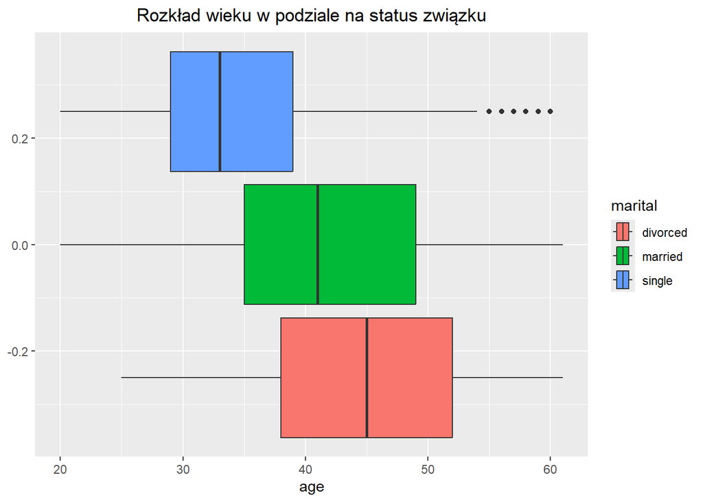

```r
df %>%
  filter(contact == "unknown") %>%
  ggplot(aes(x = age, fill = marital)) +
  geom_boxplot() +
  labs(title = strwrap("Rozkład wieku w podziale na status związku")) +
  theme(plot.title = element_text(hjust = 0.5))
```

**Komentarz:** Dla osób które mają nieznany sposób kontaktu zauważamy że w grupie osób rozwiedzonych średnia wieku jest największa, zaś w grupie osób nie bedących w związku średnia wieku jest najmniejsza. Te grupy na siebie nachodzą jednak widać jasną zależność miedzy wiekiem a podziałem na status związku.

## Zadanie 3

Jaka jest różnica pomiędzy średnim rocznym saldem w euro w zależności od wykształcenia i tego czy kredyt jest niespłacany?

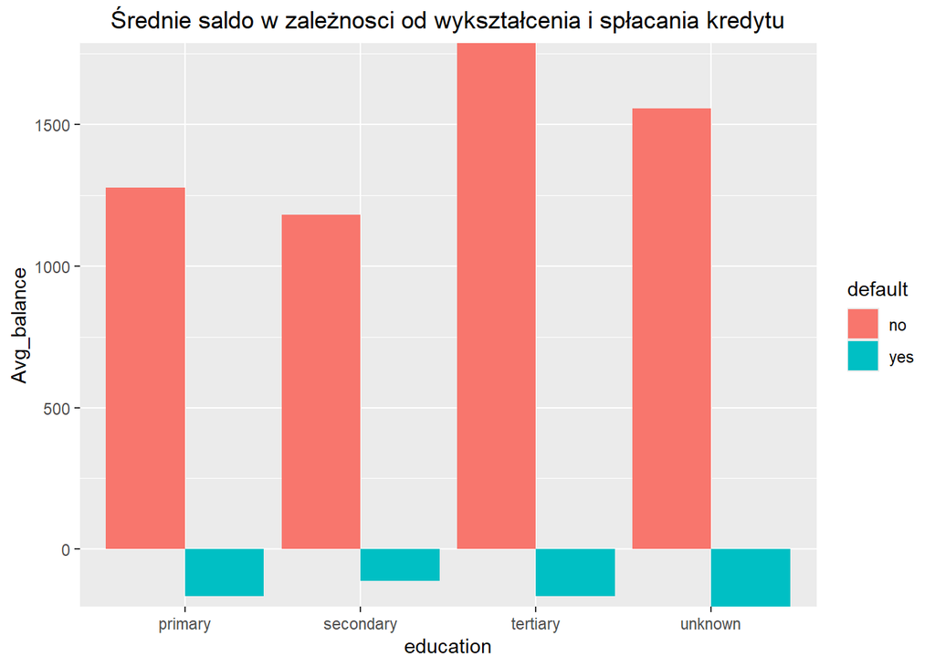

```r
df %>%
  group_by(education,default) %>%
  summarise(Avg_balance = mean(balance)) %>%
  ggplot( aes(x = education, y = Avg_balance, fill = default)) +
  geom_bar(stat = "identity", position = "dodge") +
  scale_y_continuous(expand= c(0,0)) +
  labs(title = strwrap("Średnie saldo w zależnosci od wykształcenia i spłacania kredytu")) +
  theme(plot.title = element_text(hjust = 0.5))
```

**Komentarz:** Dla grupy osób które spłacają kredyt najwyższe średnie saldo mają osoby z wykształceniem wyższym, a najniższe z wykształceniem średnim. Natomiast dla osób które nie spłacają kredytu wszystkie średnie salda są ujemne ale najmniejsze zadłużenie mają osoby z wykształceniem średnim a największe z nieznanym wykształceniem.

## Zadanie 4

Czy dzień i miesiąc kontaktu z klientem ma wpływ na średni czas trwania rozmowy w stosunku do średniego czasu trwania rozmowy?

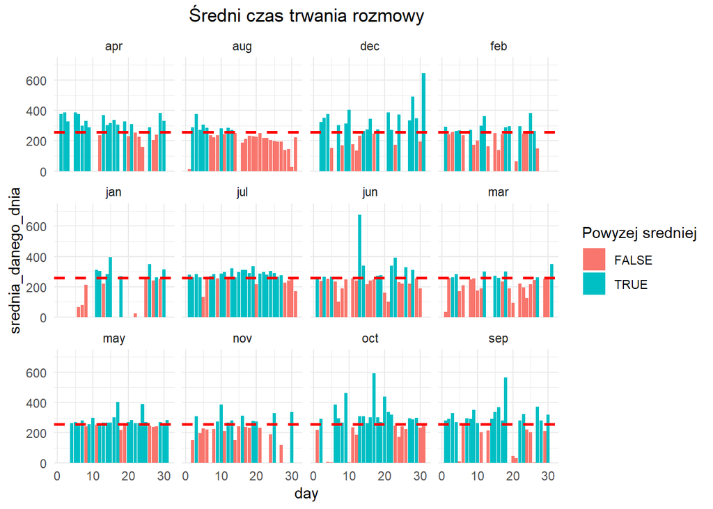

```r
srednia_ogolnie <- mean(df$duration)

df %>%
  group_by(month,day) %>%
  summarise(srednia_danego_dnia = mean(duration)) %>%
  ggplot(aes(x = day, y = srednia_danego_dnia, fill = srednia_danego_dnia > srednia_ogolnie)) +
  geom_col() +
  geom_hline(yintercept = srednia_ogolnie, linetype = "dashed", color = "red", size = 1) +
  facet_wrap(~month) +
  scale_y_continuous(limits = c(0, 750), expand = c(0, 0)) +
  theme_minimal() +
  labs(fill = "Powyzej sredniej") +
  labs(title = strwrap("Średni czas trwania rozmowy")) +
  theme(plot.title = element_text(hjust = 0.5))
```

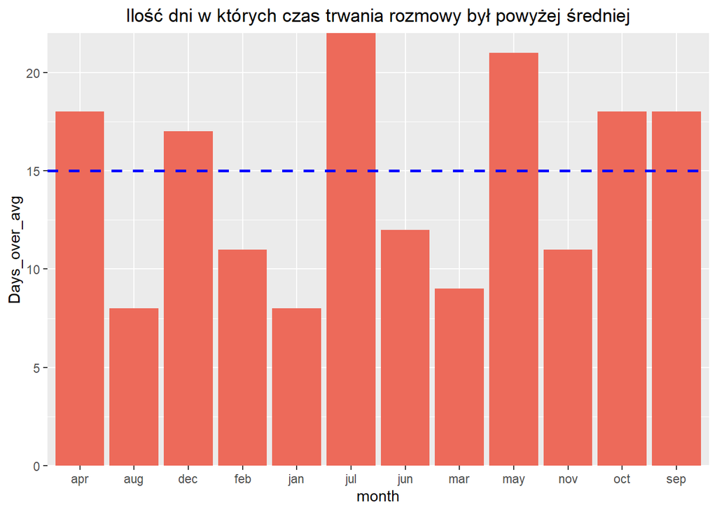

```r
df %>%
  group_by(month, day) %>%
  summarise(srednia_danego_dnia = mean(duration)) %>%
  filter(srednia_danego_dnia > srednia_ogolnie) %>%
  summarise(Days_over_avg = n()) %>%
  ggplot(aes(x = month, y=Days_over_avg)) +
  geom_col(fill = "#ed6a5a") +
  geom_hline(yintercept = 15,linetype = "dashed", color = "blue", size = 1 ) +
  scale_y_continuous( expand = c(0, 0)) +
  labs(title = strwrap("Ilość dni w których czas trwania rozmowy był powyżej średniej")) +
  theme(plot.title = element_text(hjust = 0.5))
```

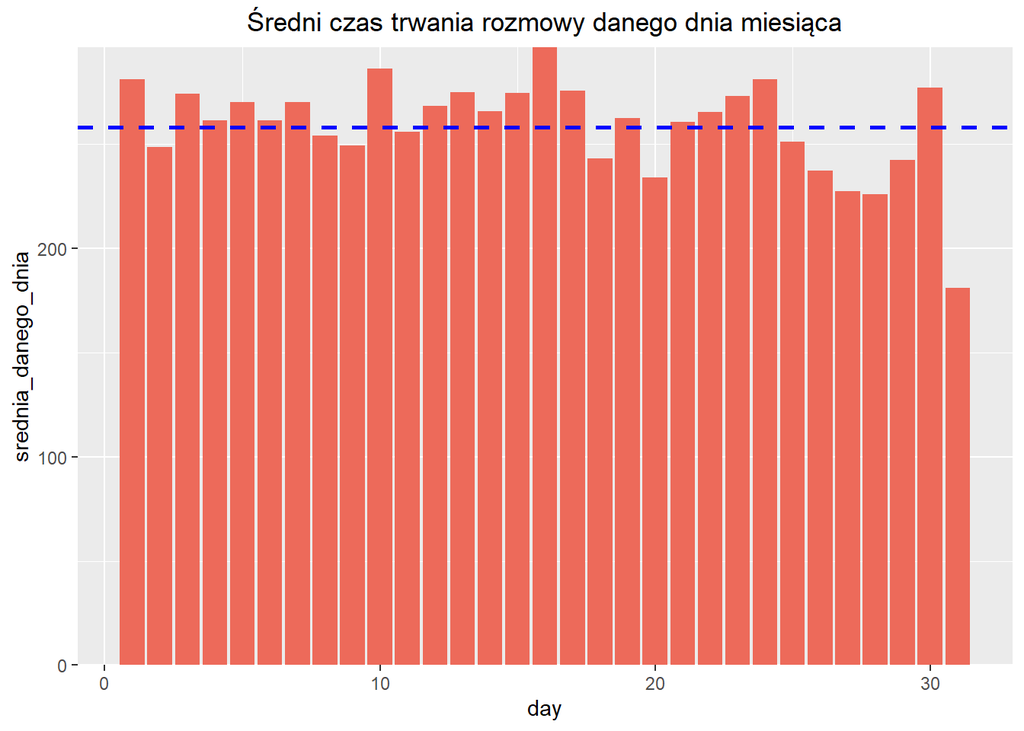

```r
df %>%
  group_by(day) %>%
  summarise(srednia_danego_dnia = mean(duration)) %>%
  ggplot(aes(x = day, y=srednia_danego_dnia)) +
  geom_col(fill = "#ed6a5a") +
  geom_hline(yintercept = srednia_ogolnie,linetype = "dashed", color = "blue", size = 1 ) +
  scale_y_continuous( expand = c(0, 0)) +
  labs(title = strwrap("Średni czas trwania rozmowy danego dnia miesiąca")) +
  theme(plot.title = element_text(hjust = 0.5))
```

## Zadanie 5

Czy jest zależnośc pomiędzy wiekiem klientów a ich średnim rocznym saldzie w euro w podziale na stopień wykształcenia?

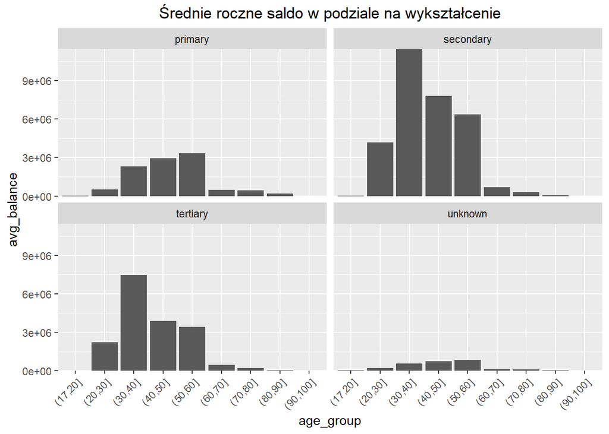

```r
df %>%
  filter(!is.na(age)) %>%
  mutate(age_group = cut(age, c(17,20,30,40,50,60,70,80,90,100))) %>%
  group_by(age_group) %>%
  mutate(avg_balance = mean(balance)) %>%
  ggplot(aes(x = age_group, y = avg_balance)) +
  geom_col() +
  theme(axis.text.x = element_text(angle = 45, hjust = 1)) +
  facet_wrap(~education) +
  scale_y_continuous(expand = c(0, 0)) +
  labs(title = strwrap("Średnie roczne saldo w podziale na wykształcenie")) +
  theme(plot.title = element_text(hjust = 0.5))
```

**Komentarz:** Dla wykształcenia podstawowego i nieznanego widzimy tendencję wzrostową średniego balansu do wieku 60 lat po czym następuje spadek, zaś dla wykształcenia średniego i wyższego dla grupy 30-40 lat zawuażalny jest drastyczny wzrost lecz poźniej następuje tendencja spadkowa.

## Zadanie 6

Rozważmy osoby, które są bezrobotne albo ich zawód jest nieznany. Czy procent osób, które są bezrobotne i nie spłacają kredytu jest większy od procenta osób o nieznanym zawodzie i nie spłacanym kredycie? Jaki typ kredytu jest (przez te osoby) najczęściej niespłacany?

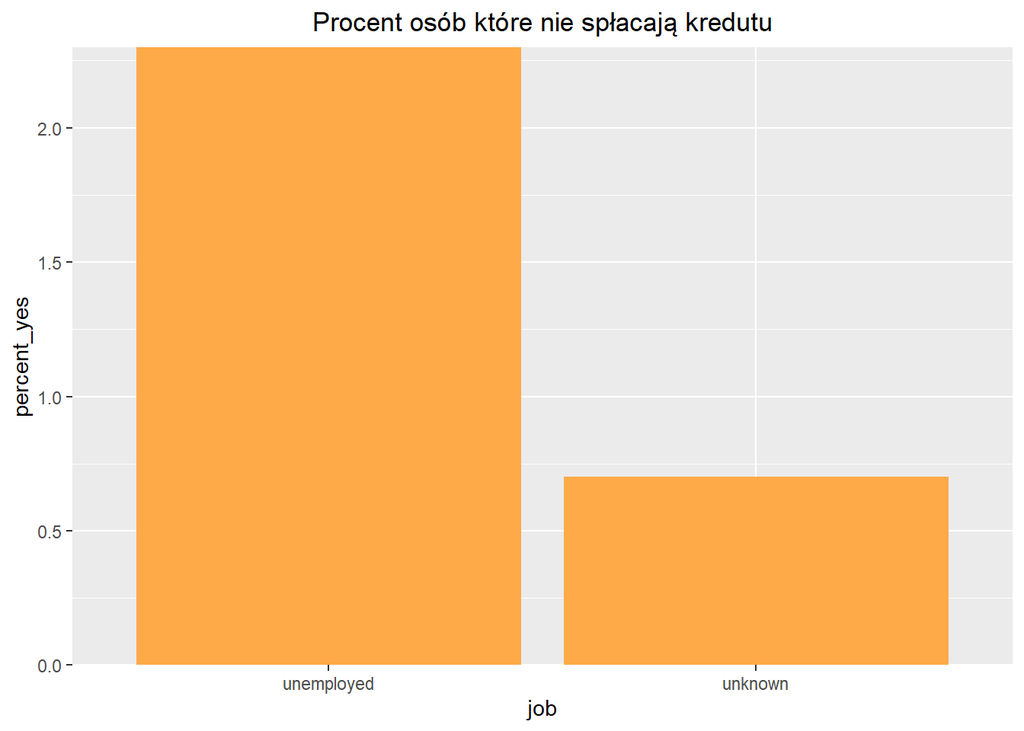

```r
df %>%
  filter(( job == "unknown" | job == "unemployed")) %>%
  group_by(job) %>%
  summarise(percent_yes = round(100 * sum(default == "yes") / n(), 1)) %>%
  ggplot(aes(x=job, y= percent_yes)) +
  geom_col(fill = "#FFAA48") +
  scale_y_continuous(expand = c(0, 0)) +
  labs(title = strwrap("Procent osób które nie spłacają kredutu")) +
  theme(plot.title = element_text(hjust = 0.5))
```

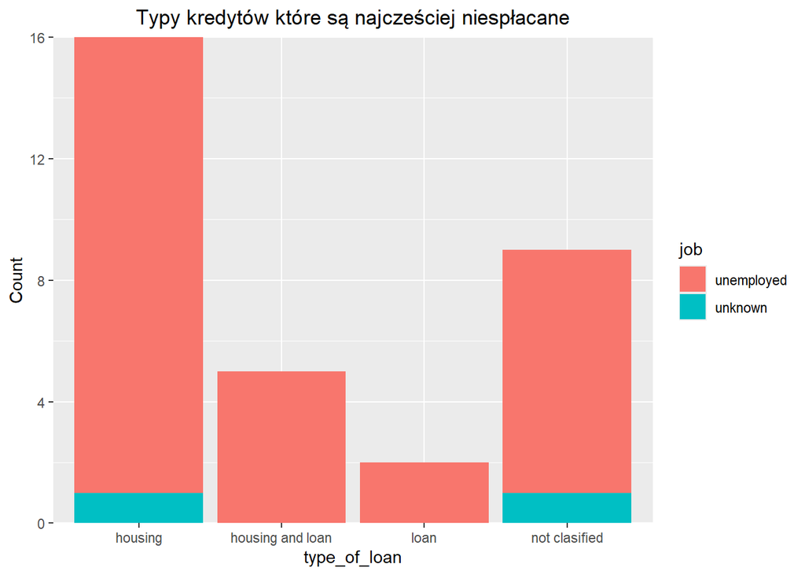

```r
df %>%
  filter((job == "unemployed"| job == "unknown") & default == "yes" ) %>%
  mutate(type_of_loan = case_when(
    housing == "yes" & loan =="no" ~ "housing",
    housing == "no" & loan =="yes" ~ "loan",
    housing == "yes" & loan =="yes" ~ "housing and loan",
    TRUE ~ "not clasified"
                                 )) %>%
  group_by(job, type_of_loan) %>%
  summarise(Count = n()) %>%
  drop_na() %>%
  ggplot(aes(x = type_of_loan, y = Count, fill=job)) +
  geom_col() +
  scale_y_continuous(expand = c(0, 0)) +
  labs(title = strwrap("Typy kredytów które są najcześciej niespłacane")) +
  theme(plot.title = element_text(hjust = 0.5))
```

**Komentarz:** Procent osób niespłacających kredytu jest większy dla osób bezrobotnych niż osób o nieznanym zawodzie. Widzimy ze naczęstszym niespłacanym kredytem jest kredyt mieszkaniowy.